# Spike glycoprotein / E2 Glycoprotein

Fold-switch pair **5wrgC_1wyyB** — **5wrgC** vs **1wyyB**

Severe acute respiratory syndrome-related coronavirus

## Figure 1: Phylogenetic tree with per-cluster fold-preference heatmap.

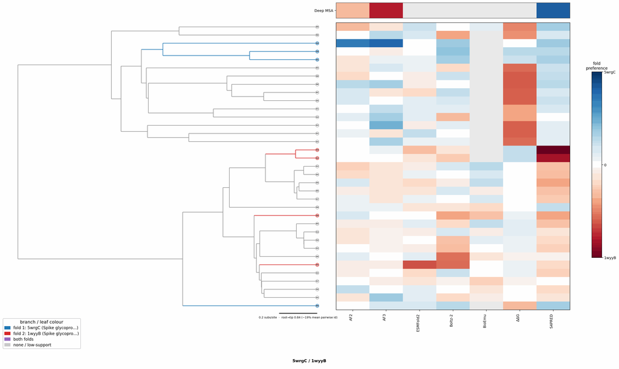

## Figure 2: Aligned overlay (both folds superposed)

The single fold-switching chain of each fold superposed by TM-align; waters hidden, any ligand shown as green sticks. Grey = structurally conserved core, colour = divergent (fold-switching) region.

5wrgC (Spike glycoprotein / E2 Glycoprotein)1wyyB (Spike glycoprotein / E2 Glycoprotein)

TM-score: 0.419 · Trigger class: mutation

Aligned overlay

Loading...

## Figure 3: The two folds, side by side

Each fold is coloured by per-residue Cα deviation between the two superposed structures: grey ≈ conserved core, full colour = structurally divergent (fold-switching) region.

5wrgC (Spike glycoprotein / E2 Glycoprotein)

1wyyB (Spike glycoprotein / E2 Glycoprotein)

0 Å5≥10 Å

5wrgC (Spike glycoprotein / E2 Glycoprotein)

Loading...

1wyyB (Spike glycoprotein / E2 Glycoprotein)

Loading...

## Figure 4: Best-cluster predicted contact maps over the two true folds.

Predicted contact maps (MSA-Transformer) for the clusters best matching each fold, over the true contacts of fold 1 (upper triangle) and fold 2 (lower). Divergent contacts between clusters are the contact-level signature of fold-switching.

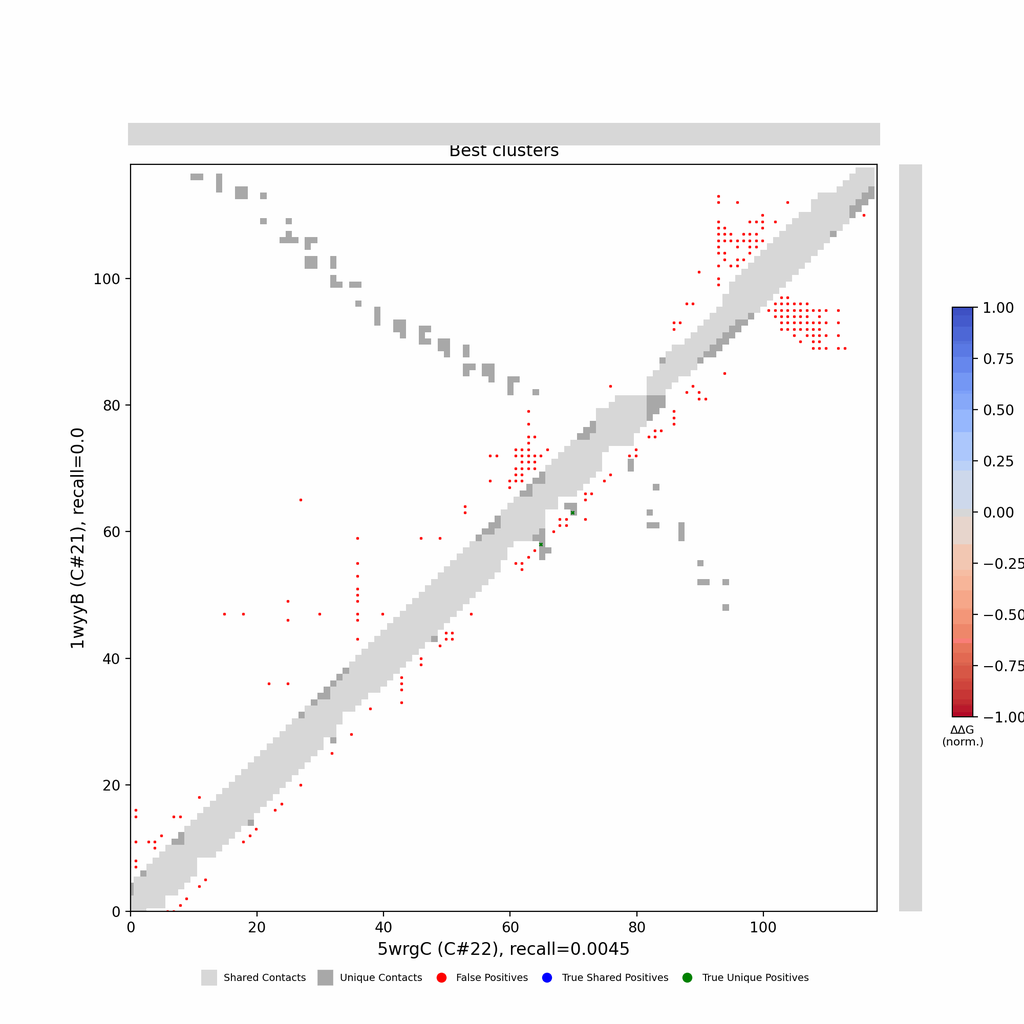

## Figure 5: Per-residue ΔΔG fold-preference contribution

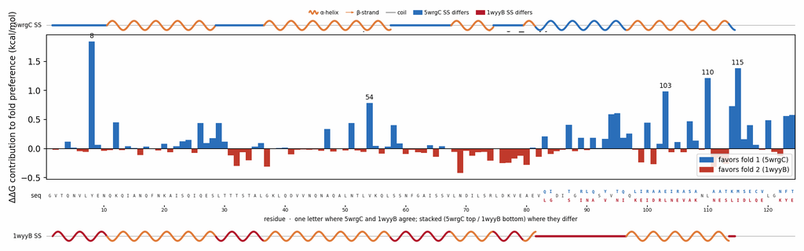

**More figures**

## Figure 6: Deep-MSA contact map panel / Best clusters contact map panel

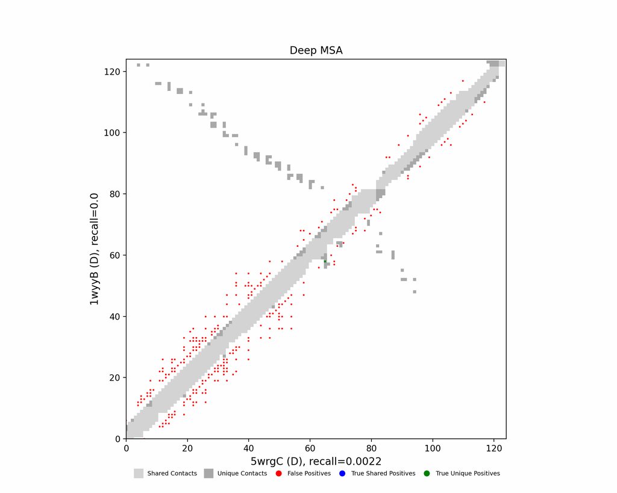

Deep-MSA contact map panel

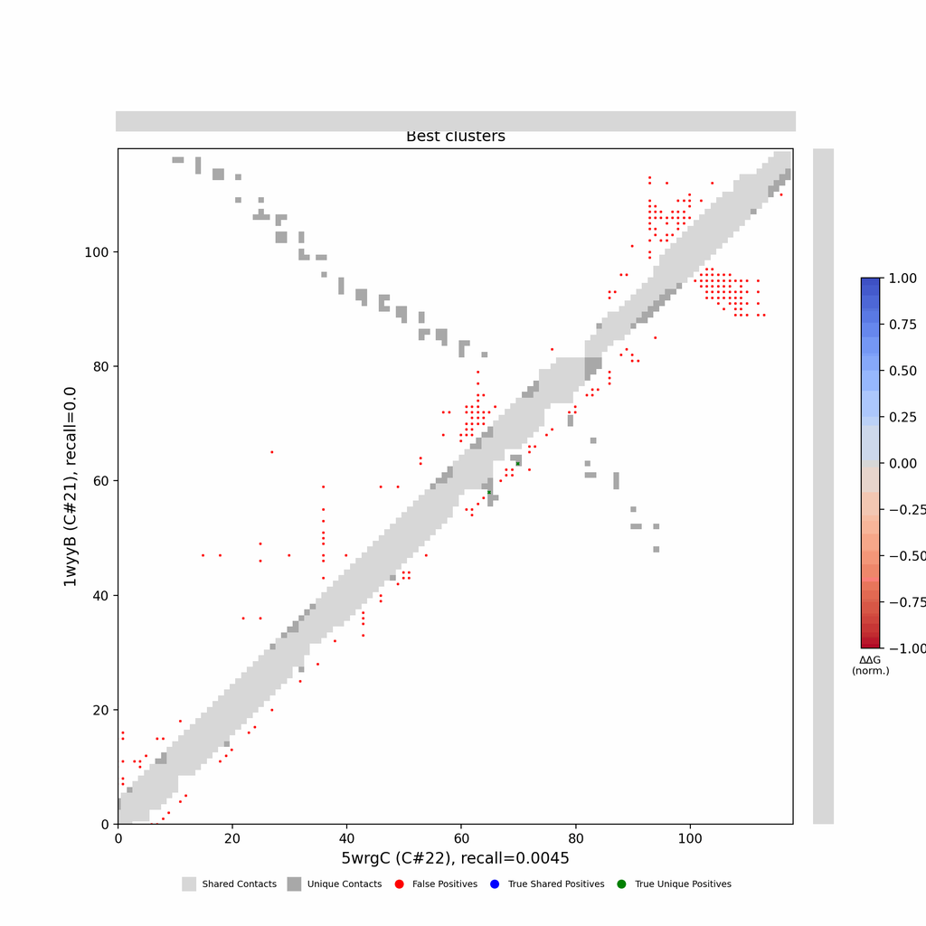

Best clusters contact map panel

## Figure 7: All clusters contact-map mosaic (small multiples).

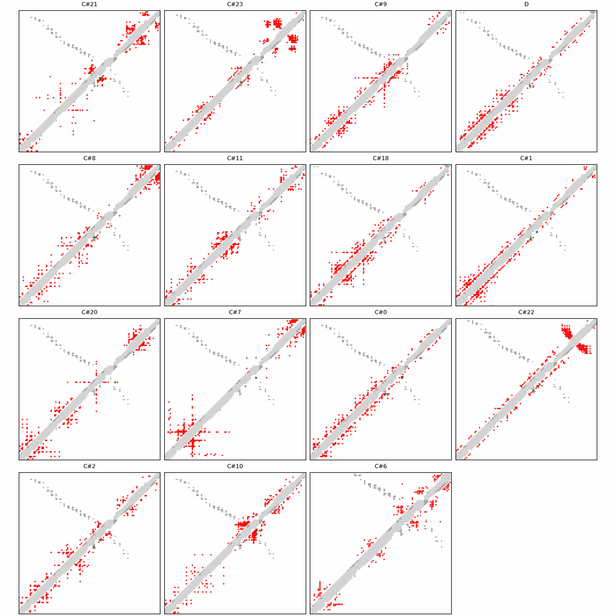

## Figure 8: Phylo null: tree with shuffled cluster fold labels.

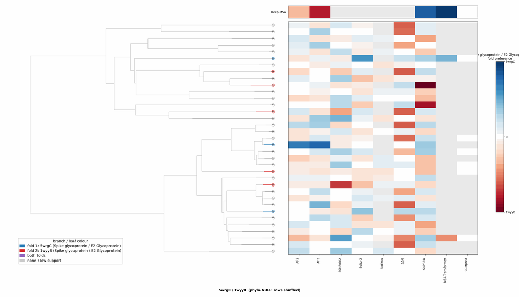

## Cluster metrics table

Per-cluster metrics underlying the figures above.

| cluster | n | neff | AF2_TM1 | AF2_TM2 | AF3_TM1 | AF3_TM2 | RE-MSAT-COM | RE-MSAT1 | RE-MSAT2 | ESM_SEQIDS | ESM_TM1 | ESM_TM2 | ΔΔG_Bias | ΔΔG_Bias_std | ΔΔG_frac_F1 | Boltz2_pref | S4PRED_pref | CCMpred_pref | BioEmu_pref |
| --- | --- | --- | --- | --- | --- | --- | --- | --- | --- | --- | --- | --- | --- | --- | --- | --- | --- | --- | --- |
| Deep | - | - | 0.48 | 0.62 | 0.34 | 0.71 | 0.0 | 0.08 | 0.0 | - | - | - | - | - | - | - | 0.4 | 0.0 | - |
| 000 | 153.0 | 43.0 | 0.12 | 0.58 | 0.14 | 0.6 | 0.0 | 0.06 | 0.0 | 006; 006; 005; 005; 008; 008; 007; 007; 001; 003 | 0.23 ± 0.04 | 0.47 ± 0.08 | -104.53 | 25.14 | 0.0 | -0.21 | 0.4 | 0.0 | -0.18 |
| 001 | 20.0 | 8.0 | 0.21 | 0.57 | 0.21 | 0.58 | 0.0 | 0.02 | 0.0 | 008; 008; 004; 004; 001; 007; 007; 005; 001; 005 | 0.22 ± 0.01 | 0.44 ± 0.10 | -19.17 | 7.82 | 0.0 | -0.05 | 0.39 | 0.0 | - |
| 002 | - | - | 0.15 | 0.52 | 0.22 | 0.56 | 0.0 | 0.01 | 0.0 | - | - | - | -114.6 | 4.78 | 0.0 | -0.33 | 0.34 | 0.0 | - |
| 003 | 14.0 | 4.0 | 0.17 | 0.53 | 0.16 | 0.6 | - | 0.01 | - | - | - | - | -36.16 | 2.5 | 0.0 | -0.33 | 0.09 | 0.0 | -0.14 |
| 004 | 14.0 | 1.0 | 0.28 | 0.59 | 0.28 | 0.61 | - | 0.07 | - | - | - | - | -84.36 | 35.84 | 0.0 | -0.08 | 0.4 | 0.0 | - |
| 005 | 14.0 | 13.0 | 0.15 | 0.51 | 0.13 | 0.6 | - | 0.01 | - | - | - | - | -46.17 | 1.0 | 0.0 | -0.16 | 0.1 | 0.0 | -0.23 |
| 006 | 13.0 | 1.0 | 0.2 | 0.52 | 0.33 | 0.6 | 0.0 | 0.03 | 0.0 | - | - | - | -101.47 | 5.12 | 0.0 | -0.44 | 0.3 | - | - |
| 007 | 12.0 | 4.0 | 0.17 | 0.41 | 0.2 | 0.65 | 0.0 | 0.04 | 0.0 | - | - | - | -117.33 | 2.49 | 0.0 | -0.1 | 0.31 | - | - |
| 008 | 12.0 | 1.0 | 0.15 | 0.55 | 0.22 | 0.62 | 0.0 | 0.03 | 0.0 | - | - | - | -120.43 | 3.7 | 0.0 | -0.12 | 0.35 | - | - |
| 009 | - | - | 0.24 | 0.43 | 0.19 | 0.43 | 0.0 | 0.0 | 0.0 | - | - | - | -118.7 | 2.2 | 0.0 | -0.22 | 0.36 | - | - |
| 010 | - | - | 0.23 | 0.5 | 0.28 | 0.53 | 0.0 | 0.01 | 0.0 | - | - | - | -94.27 | 4.45 | 0.0 | -0.4 | 0.25 | - | - |
| 011 | 11.0 | 2.0 | 0.16 | 0.44 | 0.16 | 0.62 | 0.0 | 0.0 | 0.0 | - | - | - | -118.08 | 2.99 | 0.0 | -0.22 | 0.29 | - | - |
| 012 | 11.0 | 3.0 | 0.22 | 0.53 | 0.2 | 0.6 | - | 0.0 | - | - | - | - | -17.48 | 1.26 | 0.0 | -0.37 | -0.17 | - | - |
| 013 | 11.0 | 5.0 | 0.13 | 0.56 | 0.16 | 0.62 | - | 0.01 | - | - | - | - | -45.49 | 1.38 | 0.0 | -0.17 | 0.09 | - | -0.13 |
| 014 | 11.0 | 2.0 | 0.17 | 0.53 | 0.18 | 0.6 | - | 0.0 | - | - | - | - | -35.76 | 0.87 | 0.0 | -0.14 | 0.16 | - | -0.23 |
| 015 | 11.0 | 1.0 | 0.18 | 0.51 | 0.18 | 0.6 | - | 0.0 | - | - | - | - | -39.49 | 3.05 | 0.0 | -0.39 | 0.12 | - | -0.2 |
| 016 | 11.0 | 1.0 | 0.14 | 0.5 | 0.17 | 0.59 | - | 0.0 | - | - | - | - | -37.81 | 1.19 | 0.0 | -0.38 | 0.14 | - | -0.18 |
| 017 | 11.0 | 1.0 | 0.2 | 0.52 | 0.2 | 0.63 | - | 0.0 | - | - | - | - | -50.11 | 22.7 | 0.0 | -0.25 | 0.24 | - | -0.27 |
| 018 | - | - | 0.22 | 0.52 | 0.18 | 0.62 | 0.0 | 0.04 | 0.0 | - | - | - | -13.13 | 5.83 | 0.1 | -0.02 | 0.37 | - | - |
| 019 | 11.0 | 1.0 | 0.21 | 0.2 | 0.28 | 0.31 | - | 0.06 | - | - | - | - | -47.8 | 40.44 | 0.0 | -0.04 | 0.41 | - | - |
| 020 | 11.0 | 1.0 | 0.18 | 0.41 | 0.17 | 0.56 | 0.0 | 0.0 | 0.0 | - | - | - | -118.37 | 2.62 | 0.0 | -0.14 | 0.34 | - | - |
| 021 | 11.0 | 2.0 | 0.24 | 0.54 | 0.26 | 0.55 | 0.0 | 0.02 | 0.0 | - | - | - | -94.19 | 3.53 | 0.0 | -0.18 | 0.31 | - | - |
| 022 | - | - | 0.2 | 0.5 | 0.29 | 0.54 | 0.0 | 0.01 | 0.0 | - | - | - | -113.74 | 8.37 | 0.0 | -0.19 | 0.28 | - | - |
| 023 | 10.0 | 3.0 | 0.17 | 0.49 | 0.26 | 0.43 | 0.0 | 0.01 | 0.0 | - | - | - | -117.85 | 6.79 | 0.0 | -0.19 | 0.29 | - | - |
| 024 | 10.0 | 6.0 | 0.18 | 0.48 | 0.22 | 0.6 | - | 0.0 | - | - | - | - | -16.63 | 3.99 | 0.0 | -0.29 | -0.25 | - | - |
| 025 | 10.0 | 1.0 | 0.12 | 0.53 | 0.15 | 0.62 | - | 0.0 | - | - | - | - | -45.17 | 0.94 | 0.0 | -0.23 | 0.08 | - | -0.17 |
| 026 | 10.0 | 4.0 | 0.14 | 0.39 | 0.14 | 0.61 | - | 0.0 | - | - | - | - | -44.33 | 1.93 | 0.0 | -0.26 | 0.04 | - | -0.14 |
| 027 | 10.0 | 9.0 | 0.13 | 0.42 | 0.14 | 0.62 | - | 0.0 | - | - | - | - | -47.85 | 1.62 | 0.0 | -0.23 | 0.11 | - | -0.15 |
| 028 | 10.0 | 3.0 | 0.18 | 0.48 | 0.21 | 0.58 | - | 0.01 | - | - | - | - | -42.54 | 3.5 | 0.0 | -0.28 | 0.35 | - | -0.26 |
| 029 | 10.0 | 1.0 | 0.16 | 0.39 | 0.2 | 0.61 | - | 0.0 | - | - | - | - | -40.15 | 2.63 | 0.0 | -0.43 | 0.04 | - | -0.29 |
| 030 | 10.0 | 1.0 | 0.21 | 0.48 | 0.2 | 0.6 | - | 0.0 | - | - | - | - | -50.3 | 4.09 | 0.0 | -0.52 | 0.22 | - | -0.24 |
| 031 | 10.0 | 1.0 | 0.15 | 0.49 | 0.18 | 0.6 | - | 0.0 | - | - | - | - | -40.32 | 4.72 | 0.0 | -0.52 | 0.13 | - | -0.2 |
| 032 | 10.0 | 1.0 | 0.19 | 0.53 | 0.15 | 0.57 | - | 0.0 | - | - | - | - | -39.02 | 3.42 | 0.0 | -0.12 | 0.12 | - | -0.21 |
| 033 | 10.0 | 4.0 | 0.17 | 0.53 | 0.25 | 0.49 | - | 0.01 | - | - | - | - | -45.85 | 6.29 | 0.0 | -0.32 | 0.17 | - | -0.22 |
| 034 | 10.0 | 2.0 | 0.23 | 0.44 | 0.2 | 0.59 | - | 0.0 | - | - | - | - | -42.42 | 7.06 | 0.0 | -0.24 | 0.15 | - | -0.24 |